# “Rezago habitacional en México: 2022”

José Andrés Parra Caporal

2022-12-30

# Resumen

En este trabajo se presenta el cálculo del Rezago Habitacional 2022. La información utilizada corresponde a la ENIGH del Instituto Nacional de Estadística y Geografía (INEGI) en su edición 2022. La metodología utilizada para el cálculo es conforme a los criterios publicados por la CONAVI. De igual forma se presentan los resultados estadísticos para cada uno de los componentes que conforman el rezago habitacional para dar un mejor contexto en su determinación.

# Metodología utilizada

Se considera que una vivienda está en situación de rezago habitacional cuando se cumplen por lo menos una de las siguientes características:

- La vivienda se compone se materiales deteriorados.
- La vivienda se compone de materiales regulares.
- La vivienda tiene espacios precarios.

## Materiales deteriorados

Se considera que una vivienda tiene materiales deteriorados si sus paredes se conforman por cualquiera de los siguientes materiales: Material de desecho, lámina de cartón, carrizo, bambú o palma. O si su techo esta hecho de palma o paja, lámina de cartón o material de desecho. En términos de la codificación de las variables de la ENIGH en su cuadro de vivienda (*mat_pared* y *mat_techos*), las condiciones son las siguientes:

$$pared_{det} = 1 \Rightarrow mat_{pared} =
\{1,2,4,5,9\}$$
$$techo_{det} = 1
\Rightarrow mat_{techos} = \{1,2,6,99\}$$

Considerando que una vivienda se constituye de materiales deteriorados si:

$$mat_{det} = 1 \Rightarrow pared_{det} = 1 |
techo_{det} = 1$$

## Materiales regulares

Una vivienda se compone de materiales regulares si sus paredes están hechas de lámina de asbesto o metálica o de madera. O si el techo se conforma por lámina metálica, por lamina de asbesto, por material de teja o tejaminil o por teja. Si el piso es de tierra cabe dentro de la categoría de materiales regulares. Conforme a la codificación de las variables de la ENIGH (*mat_pared*,*mat_techos* y *mat_pisos*), las condiciones son:

$$pared_{reg} = 1 \Rightarrow mat_{pared}
= \{3,6\}$$

$$techo_{reg} = 1 \Rightarrow mat_{techos}
= \{3,4,7,9\}$$

$$piso_{det} = 1 \Rightarrow mat_{pisos} =
\{1,9\}$$

Considerando que una vivienda se constituye de materiales regulares si:

$$mat_{reg} = 1 \Rightarrow pared_{reg} = 1 |
techo_{reg} = 1 | piso_{reg} = 1$$

## Precariedad en los espacios

Una vivienda tiene espacios precarios si la vivienda se encuentra en una condición de hacinamiento, es decir, cuando el número de habitantes por cuarto es mayor a 2.5. El segundo elemento es el servicio sanitario, si se cuenta o no con taza de baño.

Para calcular el hacinamiento primero se calculan los residentes promedio por cada cuarto.

$$res_{cuarto} =
\frac{residentes}{cuartos}$$

Por lo que la condición de hacinamiento es la siguiente:

$$hacin = 1 \Rightarrow res_{cuarto} >
2.5$$

Si una persona carece de escusado (si la variable *excusado* es igual a 0) se considera como una vivienda con espacios precarios. Teniendo esto en cuenta, la precariedad de los espacios se calcula como sigue:

$$prec_{esp} = 1 \Rightarrow hacin =1 |
excusado = 0$$

## Rezago de vivienda

Como se mencionó anteriormente, para calcular el rezago habitacional se consideran las tres dimensiones en los vectores calculados: *mat_det*, *mat_reg* y *prec_esp*.

$$rezago = 1 \Rightarrow mat_{det} = 1 |
mat_{reg} = 1 | prec_{esp} = 1$$

# Resultados

## Rezago habitacional

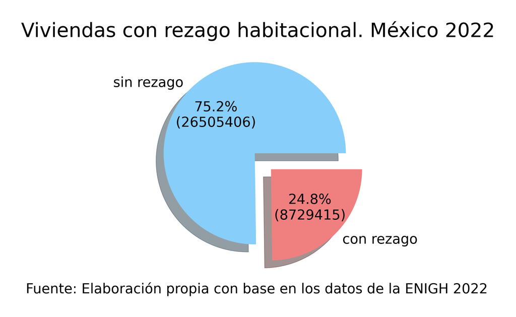

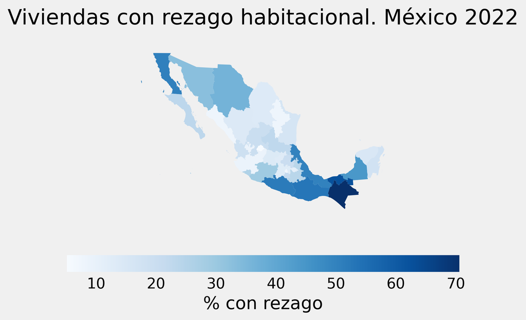

Viviendas en condición de rezago habitacional

|  | Viviendas | Con rezago | Sin rezago | % con rezago |
| --- | --- | --- | --- | --- |
| Chiapas | 1411266 | 999688 | 411578 | 70.84 |
| Tabasco | 681950 | 425311 | 256639 | 62.37 |
| Oaxaca | 1118022 | 591631 | 526391 | 52.92 |
| Guerrero | 937809 | 486748 | 451061 | 51.90 |
| Baja California | 1144066 | 580181 | 563885 | 50.71 |
| Veracruz de Ignacio de la Llave | 2370865 | 1185360 | 1185505 | 50.00 |
| Campeche | 257257 | 114235 | 143022 | 44.41 |
| Chihuahua | 1136150 | 412988 | 723162 | 36.35 |
| Sonora | 875959 | 287622 | 588337 | 32.84 |
| Michoacán de Ocampo | 1282994 | 375805 | 907189 | 29.29 |
| Colima | 228765 | 58981 | 169784 | 25.78 |
| Puebla | 1714877 | 410730 | 1304147 | 23.95 |
| Baja California Sur | 245689 | 57052 | 188637 | 23.22 |
| San Luis Potosí | 748392 | 170573 | 577819 | 22.79 |
| Morelos | 576022 | 123847 | 452175 | 21.50 |
| Hidalgo | 861222 | 173818 | 687404 | 20.18 |
| Zacatecas | 452914 | 90432 | 362482 | 19.97 |
| Nayarit | 368748 | 69208 | 299540 | 18.77 |
| Quintana Roo | 557830 | 97866 | 459964 | 17.54 |
| Tamaulipas | 1050737 | 171013 | 879724 | 16.28 |
| Yucatán | 659472 | 99497 | 559975 | 15.09 |
| Durango | 499269 | 70131 | 429138 | 14.05 |
| Guanajuato | 1597797 | 220810 | 1376987 | 13.82 |
| Coahuila de Zaragoza | 903683 | 120983 | 782700 | 13.39 |
| Querétaro | 660207 | 85424 | 574783 | 12.94 |
| México | 4618111 | 590560 | 4027551 | 12.79 |
| Tlaxcala | 335517 | 36602 | 298915 | 10.91 |
| Jalisco | 2314882 | 203724 | 2111158 | 8.80 |
| Nuevo León | 1667880 | 136395 | 1531485 | 8.18 |
| Sinaloa | 862532 | 66939 | 795593 | 7.76 |
| Ciudad de México | 2707156 | 196582 | 2510574 | 7.26 |
| Aguascalientes | 386782 | 18679 | 368103 | 4.83 |

## Viviendas con materiales deteriorados

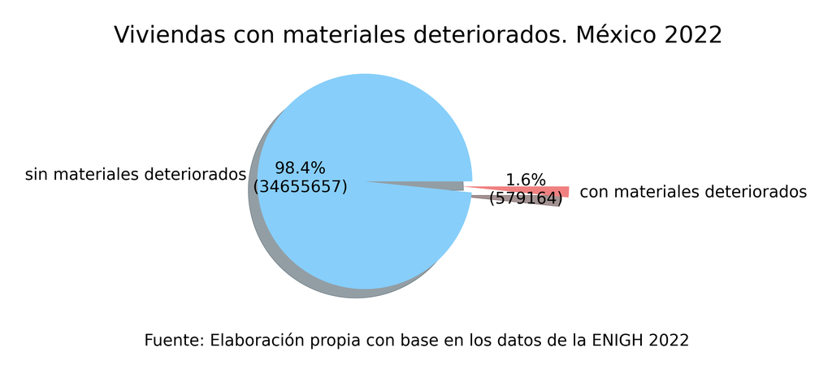

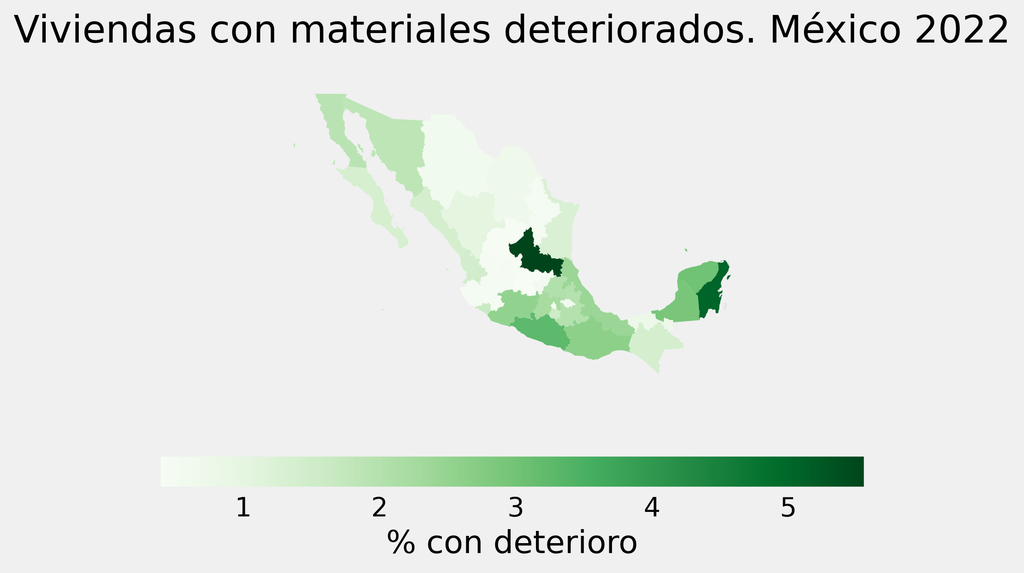

Viviendas con elementos de materiales deteriorados

|  | Viviendas | Con deterioro | Sin deterioro | % con deterioro |
| --- | --- | --- | --- | --- |
| San Luis Potosí | 748392 | 41723 | 706669 | 5.58 |
| Quintana Roo | 557830 | 28109 | 529721 | 5.04 |
| Guerrero | 937809 | 30743 | 907066 | 3.28 |
| Yucatán | 659472 | 19917 | 639555 | 3.02 |
| Campeche | 257257 | 7447 | 249810 | 2.89 |
| Oaxaca | 1118022 | 29238 | 1088784 | 2.62 |
| Michoacán de Ocampo | 1282994 | 32556 | 1250438 | 2.54 |
| Veracruz de Ignacio de la Llave | 2370865 | 57442 | 2313423 | 2.42 |
| México | 4618111 | 103207 | 4514904 | 2.23 |
| Hidalgo | 861222 | 17410 | 843812 | 2.02 |
| Puebla | 1714877 | 34454 | 1680423 | 2.01 |
| Baja California | 1144066 | 21785 | 1122281 | 1.90 |
| Sonora | 875959 | 16126 | 859833 | 1.84 |
| Colima | 228765 | 3746 | 225019 | 1.64 |
| Morelos | 576022 | 8826 | 567196 | 1.53 |
| Nayarit | 368748 | 5281 | 363467 | 1.43 |
| Sinaloa | 862532 | 12028 | 850504 | 1.39 |
| Chiapas | 1411266 | 19666 | 1391600 | 1.39 |
| Baja California Sur | 245689 | 3391 | 242298 | 1.38 |
| Tamaulipas | 1050737 | 13447 | 1037290 | 1.28 |
| Durango | 499269 | 5113 | 494156 | 1.02 |
| Tabasco | 681950 | 5416 | 676534 | 0.79 |
| Coahuila de Zaragoza | 903683 | 6214 | 897469 | 0.69 |
| Tlaxcala | 335517 | 2034 | 333483 | 0.61 |
| Chihuahua | 1136150 | 6770 | 1129380 | 0.60 |
| Querétaro | 660207 | 3734 | 656473 | 0.57 |
| Ciudad de México | 2707156 | 14429 | 2692727 | 0.53 |
| Nuevo León | 1667880 | 8143 | 1659737 | 0.49 |
| Jalisco | 2314882 | 11277 | 2303605 | 0.49 |
| Aguascalientes | 386782 | 1763 | 385019 | 0.46 |
| Zacatecas | 452914 | 1787 | 451127 | 0.39 |
| Guanajuato | 1597797 | 5942 | 1591855 | 0.37 |

## Viviendas con materiales regulares

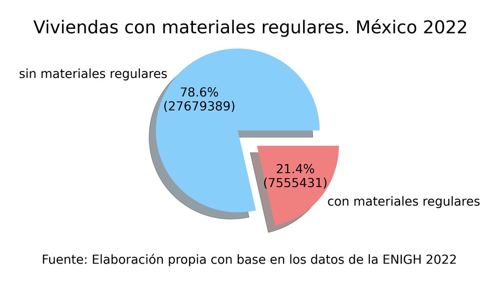

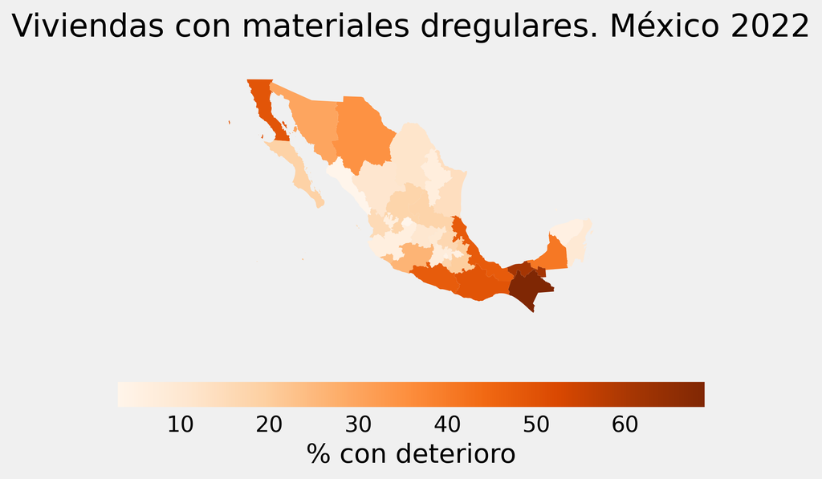

Viviendas con elementos de materiales regulares

|  | Viviendas | Con material regular | Sin material regular | % con material regular |
| --- | --- | --- | --- | --- |
| Chiapas | 1411266 | 976341 | 434925 | 69.18 |
| Tabasco | 681950 | 417901 | 264049 | 61.28 |
| Oaxaca | 1118022 | 555532 | 562490 | 49.69 |
| Baja California | 1144066 | 563618 | 580448 | 49.26 |
| Veracruz de Ignacio de la Llave | 2370865 | 1131529 | 1239336 | 47.73 |
| Guerrero | 937809 | 444225 | 493584 | 47.37 |
| Campeche | 257257 | 104833 | 152424 | 40.75 |
| Chihuahua | 1136150 | 395154 | 740996 | 34.78 |
| Sonora | 875959 | 260218 | 615741 | 29.71 |
| Michoacán de Ocampo | 1282994 | 336474 | 946520 | 26.23 |
| Colima | 228765 | 54067 | 174698 | 23.63 |
| Puebla | 1714877 | 340357 | 1374520 | 19.85 |
| Baja California Sur | 245689 | 45643 | 200046 | 18.58 |
| San Luis Potosí | 748392 | 133489 | 614903 | 17.84 |
| Zacatecas | 452914 | 79618 | 373296 | 17.58 |
| Morelos | 576022 | 100069 | 475953 | 17.37 |
| Hidalgo | 861222 | 143271 | 717951 | 16.64 |
| Nayarit | 368748 | 57340 | 311408 | 15.55 |
| Tamaulipas | 1050737 | 145962 | 904775 | 13.89 |
| Coahuila de Zaragoza | 903683 | 106134 | 797549 | 11.74 |
| Durango | 499269 | 54329 | 444940 | 10.88 |
| Guanajuato | 1597797 | 168346 | 1429451 | 10.54 |
| Querétaro | 660207 | 62896 | 597311 | 9.53 |
| Quintana Roo | 557830 | 51378 | 506452 | 9.21 |
| México | 4618111 | 358202 | 4259909 | 7.76 |
| Nuevo León | 1667880 | 110479 | 1557401 | 6.62 |
| Jalisco | 2314882 | 143373 | 2171509 | 6.19 |
| Tlaxcala | 335517 | 18703 | 316814 | 5.57 |
| Yucatán | 659472 | 34969 | 624503 | 5.30 |
| Ciudad de México | 2707156 | 126866 | 2580290 | 4.69 |
| Sinaloa | 862532 | 23819 | 838713 | 2.76 |
| Aguascalientes | 386782 | 10297 | 376485 | 2.66 |

## Viviendas con precariedad en espacios

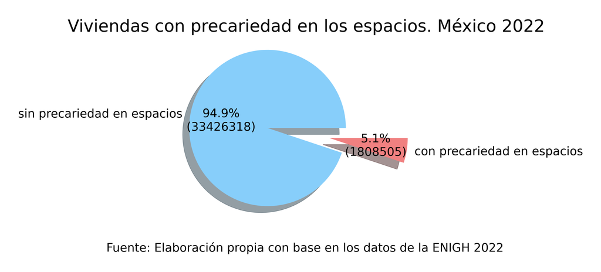

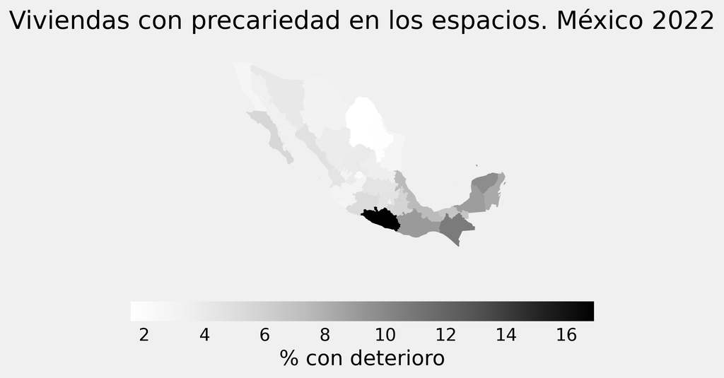

Viviendas con espacios precarios

|  | Viviendas | Con precariedad | Sin precariedad | % con precariedad |
| --- | --- | --- | --- | --- |
| Guerrero | 937809 | 159154 | 778655 | 16.97 |
| Chiapas | 1411266 | 151300 | 1259966 | 10.72 |
| Yucatán | 659472 | 64433 | 595039 | 9.77 |
| Oaxaca | 1118022 | 101086 | 1016936 | 9.04 |
| Campeche | 257257 | 22816 | 234441 | 8.87 |
| Quintana Roo | 557830 | 46221 | 511609 | 8.29 |
| Veracruz de Ignacio de la Llave | 2370865 | 174979 | 2195886 | 7.38 |
| Tabasco | 681950 | 46128 | 635822 | 6.76 |
| Tlaxcala | 335517 | 19698 | 315819 | 5.87 |
| Puebla | 1714877 | 98156 | 1616721 | 5.72 |
| Baja California Sur | 245689 | 13582 | 232107 | 5.53 |
| Morelos | 576022 | 31677 | 544345 | 5.50 |
| Michoacán de Ocampo | 1282994 | 67068 | 1215926 | 5.23 |
| Sinaloa | 862532 | 40059 | 822473 | 4.64 |
| México | 4618111 | 210695 | 4407416 | 4.56 |
| Guanajuato | 1597797 | 71971 | 1525826 | 4.50 |
| Nayarit | 368748 | 16535 | 352213 | 4.48 |
| Hidalgo | 861222 | 38037 | 823185 | 4.42 |
| Querétaro | 660207 | 29038 | 631169 | 4.40 |
| Sonora | 875959 | 35903 | 840056 | 4.10 |
| Zacatecas | 452914 | 17853 | 435061 | 3.94 |
| Durango | 499269 | 19171 | 480098 | 3.84 |
| San Luis Potosí | 748392 | 26797 | 721595 | 3.58 |
| Chihuahua | 1136150 | 35937 | 1100213 | 3.16 |
| Ciudad de México | 2707156 | 83306 | 2623850 | 3.08 |
| Jalisco | 2314882 | 70286 | 2244596 | 3.04 |
| Baja California | 1144066 | 32558 | 1111508 | 2.85 |
| Tamaulipas | 1050737 | 29544 | 1021193 | 2.81 |
| Colima | 228765 | 6396 | 222369 | 2.80 |
| Aguascalientes | 386782 | 7849 | 378933 | 2.03 |
| Nuevo León | 1667880 | 26885 | 1640995 | 1.61 |
| Coahuila de Zaragoza | 903683 | 13387 | 890296 | 1.48 |

# Comentarios El total de viviendas que se consideran en esta muestra son cerca de 35.2 millones, encontrandose 24.8% en condición de rezago habitacional. Las zona sur del país peseta un nivel relativamente más alto de esta métrica: Chiapas, Tabasco, Oaxaca y Guerrero son los estados que presentan una mayor proporción de rezago habitacional, siendo para todos estos estados una proporción mayor al 50% de las viviendas cuyos materiales son deteriorados o regulares, o que tienen espacios de vivienda precarios.